# Introduction to Programming

# The call stack

- Remember

```r
fahr_to_kelvin <- function(f) {
  k <- (f - 32) * (5 / 9) + 273.15
  return(k)
}
kelvin_to_celcius <- function(k) {
  c <- k - 273.15
  return(c)
}
fahr_to_celcius <- function(f) {
  k <- fahr_to_kelvin(f)
  c <- kelvin_to_celcius(k)
  return(c)
}
fahrenheit <- 32
celcius    <- fahr_to_celcius(fahrenheit)
```

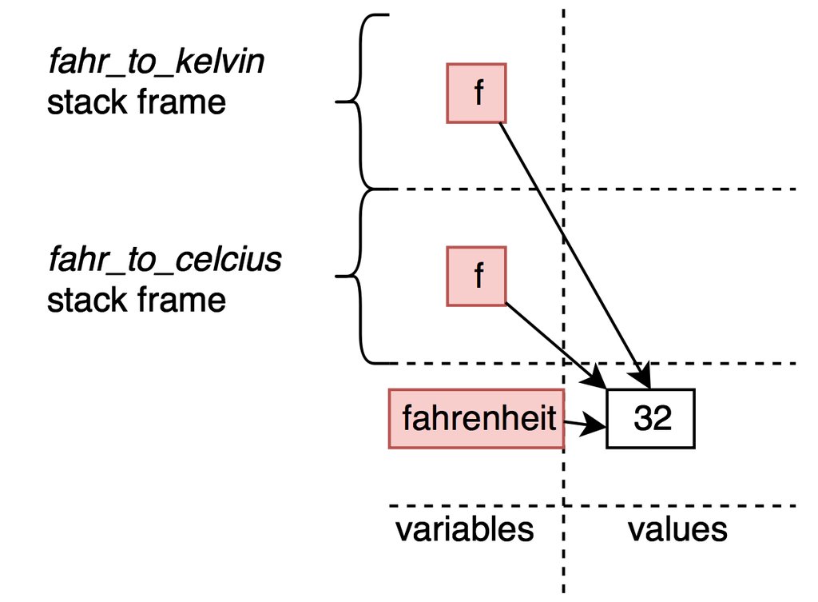

# The call stack

- Remember

```r
fahr_to_kelvin <- function(f) {
  k <- (f - 32) * (5 / 9) + 273.15
  return(k)
}
kelvin_to_celcius <- function(k) {
  c <- k - 273.15
  return(c)
}
fahr_to_celcius <- function(f) {
  k <- fahr_to_kelvin(f)
  c <- kelvin_to_celcius(k)
  return(c)
}
fahrenheit <- 32
celcius    <- fahr_to_celcius(fahrenheit)
```

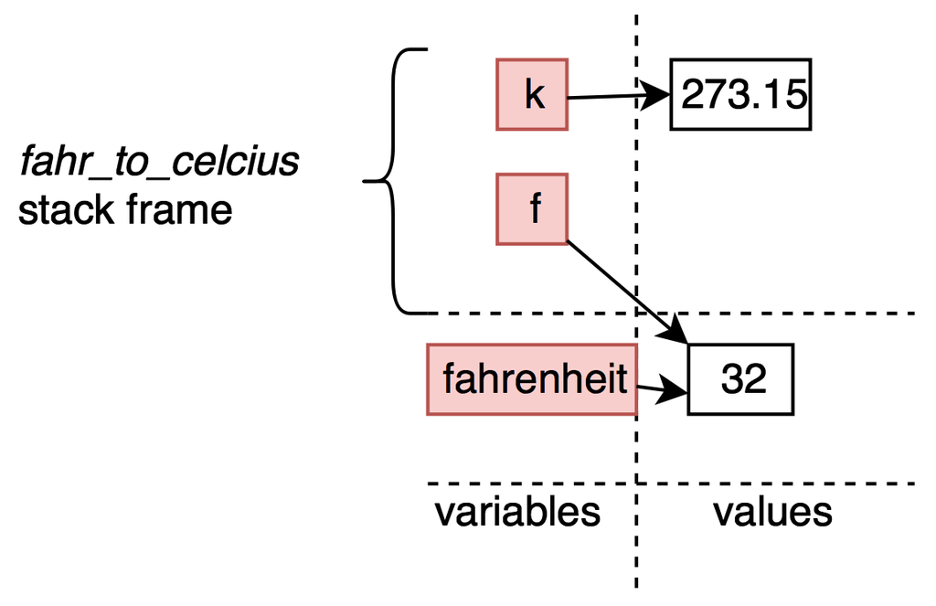

# The call stack

- Remember

```r
fahr_to_kelvin <- function(f) {
  k <- (f - 32) * (5 / 9) + 273.15
  return(k)
}
kelvin_to_celcius <- function(k) {
  c <- k - 273.15
  return(c)
}
fahr_to_celcius <- function(f) {
  k <- fahr_to_kelvin(f)
  c <- kelvin_to_celcius(k)
  return(c)
}
fahrenheit <- 32
celcius    <- fahr_to_celcius(fahrenheit)
```

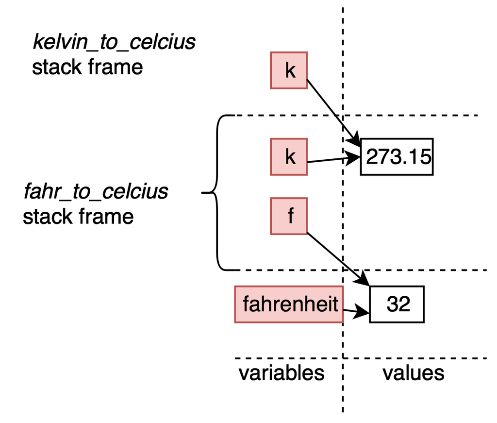

# The call stack

- Remember

```r
fahr_to_kelvin <- function(f) {
  k <- (f - 32) * (5 / 9) + 273.15
  return(k)
}
kelvin_to_celcius <- function(k) {
  c <- k - 273.15
  return(c)
}
fahr_to_celcius <- function(f) {
  k <- fahr_to_kelvin(f)
  c <- kelvin_to_celcius(k)
  return(c)
}
fahrenheit <- 32
celcius    <- fahr_to_celcius(fahrenheit)
```

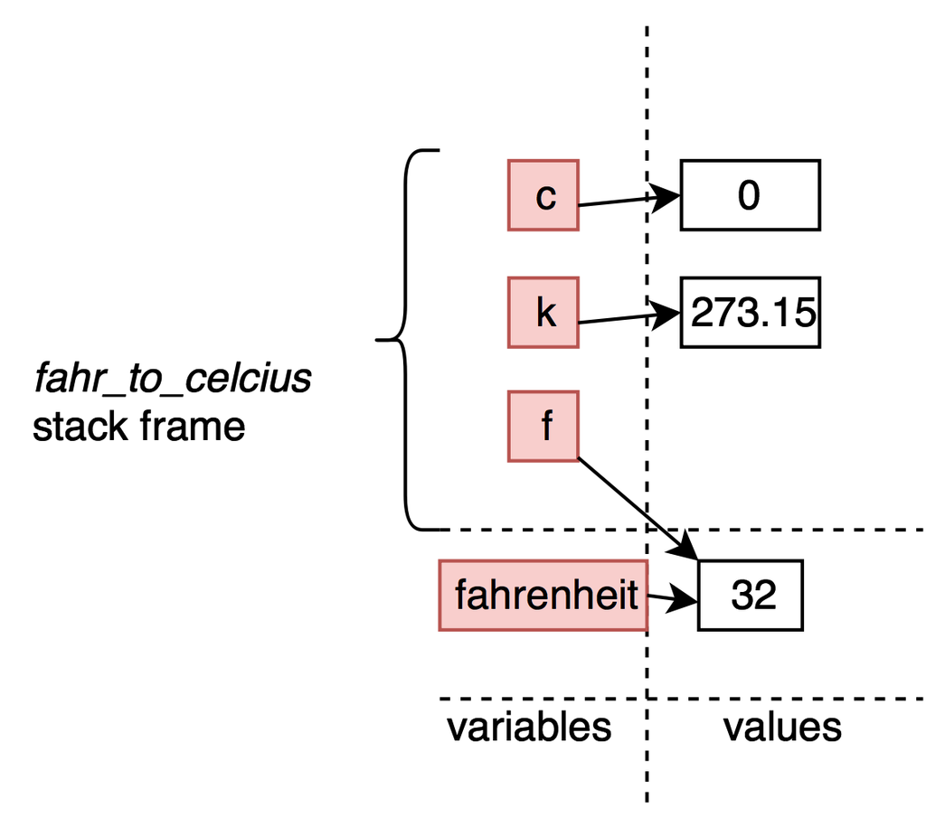

# The call stack

- Remember

```r
fahr_to_kelvin <- function(f) {
  k <- (f - 32) * (5 / 9) + 273.15
  return(k)
}
kelvin_to_celcius <- function(k) {
  c <- k - 273.15
  return(c)
}
fahr_to_celcius <- function(f) {
  k <- fahr_to_kelvin(f)
  c <- kelvin_to_celcius(k)
  return(c)
}
fahrenheit <- 32
celcius    <- fahr_to_celcius(fahrenheit)
```

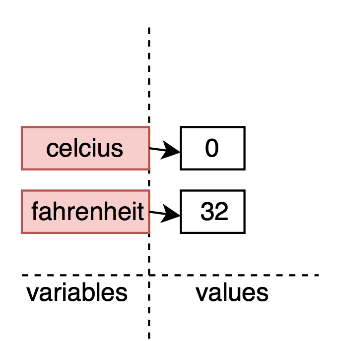

# The call stack: summary

- A stack frame: a data structure that provides storage for a function’s local variables
- Why need a stack frame? If were not there, the calculation within `fahr_to_kelvin` would affect variables outside the function (if share the same name)

# Small exercice

# Exercice #1

- Using the base function `c` and `rep`, write a function that takes three arguments, say $x$, $y$, and $n$, and returns a new vector with $x$ at the beginning and at the end, and $n$ times $y$ in the middle

# Solution

```r
repeater <- function(x, y, n) {
  return(c(x, rep(y, times = n), x))
}
repeater("yo","dawg",5)
```

```
## [1] "yo"   "dawg" "dawg" "dawg" "dawg" "dawg" "yo"
```

# Testing and documenting: keys to the BLRs

# Testing: so painful, so useful

- As soon as working with functions, need to ensure that those are working correctly
- Create a function that centers a dataset around a particular value, and test it on our data set

```r
center <- function(data, new_mean) {
  new_data <- (data - mean(data)) + new_mean
  return(new_data)
}
d        <- read.csv(file = "data/inflammation-01.csv", header = FALSE)
centered <- center(d[, 4], 0)
```

# Testing: so painful, so useful

- How to test the function `centered`?
  - standard deviation should not be affected
  - linear transformation

# Testing: so painful, so useful

- How to test the function `centered`?
  - standard deviation should not be affected
  - linear transformation

```r
sd(d[, 4])
```

```
## [1] 1.067628
```

```r
sd(centered)
```

```
## [1] 1.067628
```

# Testing with the `testthat` package

- `testthat` renders testing less painful

```r
install.packages("testthat")
```

```r
require("testthat")
# define our tests
test_that("Testing the function centered", {
  expect_true( sd(d[, 4])     == sd(centered),               "equal sd")
  expect_true( min(centered)  == min(d[,4 ]) - mean(d[,4 ]), "min difference")
  expect_true( max(centered)  == max(d[,4 ]) - mean(d[,4 ]), "max difference")
  expect_true( mean(centered) == 0,                          "mean difference")
})
```

- Be aware of potential numerical approximations (see `all.equal(x,y)`)

# Documenting

- Documentation is useful for you, and for others

```r
center <- function(data, desired) {
  # return a new vector containing the original data centered around the desired value.
  # example: center(c(1, 2, 3), 0) => c(-1, 0, 1)
  new_data <- (data - mean(data)) + desired
  return(new_data)
}
```

# Small exercice

# Exercice #2

- Write a function that takes as argument a filename and plot the `average`, the `min` and the `max` inflammation over time (as in the previous lecture)
- Do not forget to document your function

# Exercice #2: solution

```r
analyze <- function(filename) {
  # plots the average, min, and max inflammation over time
  # input is character string of a csv file
  # example: analyze("data/inflammation-03.csv")
  d <- read.csv(file = filename, header = FALSE)
  plot(apply(d, 2, mean))
  plot(apply(d, 2, max))
  plot(apply(d, 2, min))
}
```

# Default arguments

# Defaults arguments

- Remember the `read.csv` function?

```r
d <- read.csv("data/inflammation-01.csv", header = FALSE)
d <- read.csv("data/inflammation-01.csv", FALSE)
d <- read.csv(header = FALSE, file = "data/inflammation-01.csv")
d <- read.csv(FALSE, "data/inflammation-01.csv")
```

```
## Error in read.table(file = file, header = header, sep = sep, quote = quote, : 'file' must be a character string or connection
```

# Matching arguments

- R matches the arguments supplied to the function’s arguments in three ways (and in order)
  1. by complete name
  2. by partial name (initial $n$ characters)
  3. by position
- Therefore
  - arguments’ name provided: no problem
  - arguments in the correct order: no problem
  - no name and wrong order: function fails
- To be sure of the order, check the `help`

# Exercice #3: defining defaults

- **Ex**: re-define the `center` function such that the default centering is around `0`

# Exercice #3: solution

- **Ex**: re-define the `center` function such that the default centering is around `0`

```r
center <- function(data, desired = 0) {
  # return a new vector containing the original data centered around the desired value (default = 0)
  # example: center(c(1, 2, 3), 0) => c(-1, 0, 1)
  new_data <- (data - mean(data)) + desired
  return(new_data)
}
```

```r
head( center(d[,4]) )
```

```
## [1]  1.25 -0.75  1.25 -1.75  1.25  0.25
```

```r
head( center(d[,4], 0) )
```

```
## [1]  1.25 -0.75  1.25 -1.75  1.25  0.25
```

```r
head( center(desired = 0, d[,4]) )
```

```
## [1]  1.25 -0.75  1.25 -1.75  1.25  0.25
```

# Warnings & Errors

# Warnings

- When designing functions, want to be as indicative as possible one what the function is doing

```r
x = c(1,2,3); m = matrix(c(1,2,3,4,5,6),nrow=3,ncol=2)
center(x)
```

```
## [1] -1  0  1
```

```r
center(m)
```

```
##      [,1] [,2]
## [1,] -2.5  0.5
## [2,] -1.5  1.5
## [3,] -0.5  2.5
```

```r
e <- center(d)
```

```
## Warning in mean.default(data): argument is not numeric or logical:
## returning NA
```

- Would be great to inform the user about this behavior

# Warnings

- The `warning` function allows you to send warning to the user

```r
center <- function(data, desired = 0) {
  if (class(data) != "numeric" && dim(data)[2] > 1) {
    warning("the centering occurs around the mean of the entire matrix")
  }
  new_data <- (data - mean(data)) + desired
  return(new_data)
}
center(m)
```

```
## Warning in center(m): the centering occurs around the mean of the entire
## matrix
```

```
##      [,1] [,2]
## [1,] -2.5  0.5
## [2,] -1.5  1.5
## [3,] -0.5  2.5
```

# Errors

- The `stop` function allows you to stop the execution of the function, and returns an error message instead

```r
center <- function(data, desired = 0) {
  if (class(data) == "data.frame") {
    stop("cannot take the mean of a data.frame, therefore cannot center the data")
  }
  if (class(data) != "numeric" & dim(data)[2] > 1) {
    warning("the centering occurs around the mean of the entire matrix")
  }
  new_data <- (data - mean(data)) + desired
  return(new_data)
}
center(d)
```

```
## Error in center(d): cannot take the mean of a data.frame, therefore cannot center the data
```

- You can also have a look at the `tryCatch` function